# Regression Models

Tuo Liu

2024-06-21

# statistical models

## notation and foundation

All models are wrong, but some are useful: models are not an exact representation of reality; models are useful approximations for representing the necessary detail for the purpose at hand.

## statistical models=random+systematic components

consider a lung capacity experiment where lung capacity data were collected along with age, gender and smoking status. At any combination of height, age, and smoking status, many different values of lung capacity could be recorded, and so produce a distribution of recorded lung capacity values. A model for this distribution of values is called the **random component** of the statistical model. At a given combination of height, age, gender and smoking status, the distribution of lung capacity values has a mean. The mathematical relationshio between the mean and given values of the predictors is called the **systematic component** of the statistical model.

a ststistical model consists of a random component and a systematic component to explain these two features of real data. A statistical model is to mathematically represent both the systematic and random components of data.

many systematic components for the lung capacity data are possible. One simple systematic component is

$$\mu_i = \beta_0+\beta_1 x_{1i}+\beta_2 x_{2i}+\dots+\beta_px_{pi}$$
for observation i, where $\mu_i$ is the expected value of $y_i$, so that $\mu_i=E[y_i]$ for $i=1,2,\dots, n$. The $\beta_j$ are unknown regression parameters. Plotting y against exploratory variables indicates that this is a poor systematic component. the random component about this systematic components may take many forms. for example, $var[y_i]=\sigma^2$ assumes that the variance of the responses $y_i$ is constant about $\mu_i$ without assuming the distribution of the responses. A popular assumption is to assume the responses are normally distributed around $y_i$, written as $y_i \sim N(\mu_i, \sigma^2)$. Both assumptions on constant variance are likely to be poor as the variation in the observed lung capacity increases for larger values of FEV.

Combining the random and systematic component, a possible linear regression model for modelling lung capacity data is
$$\begin{cases} var[y_i]=\sigma^2 \\ \mu_i=\beta_0+\beta_1x_{1i}+\dots+\beta_px_{pi} \end{cases}$$

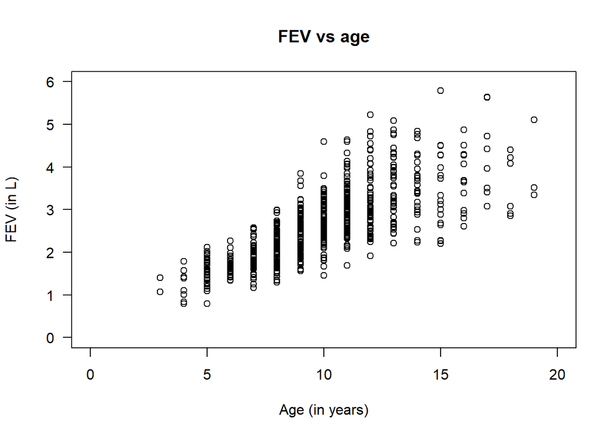

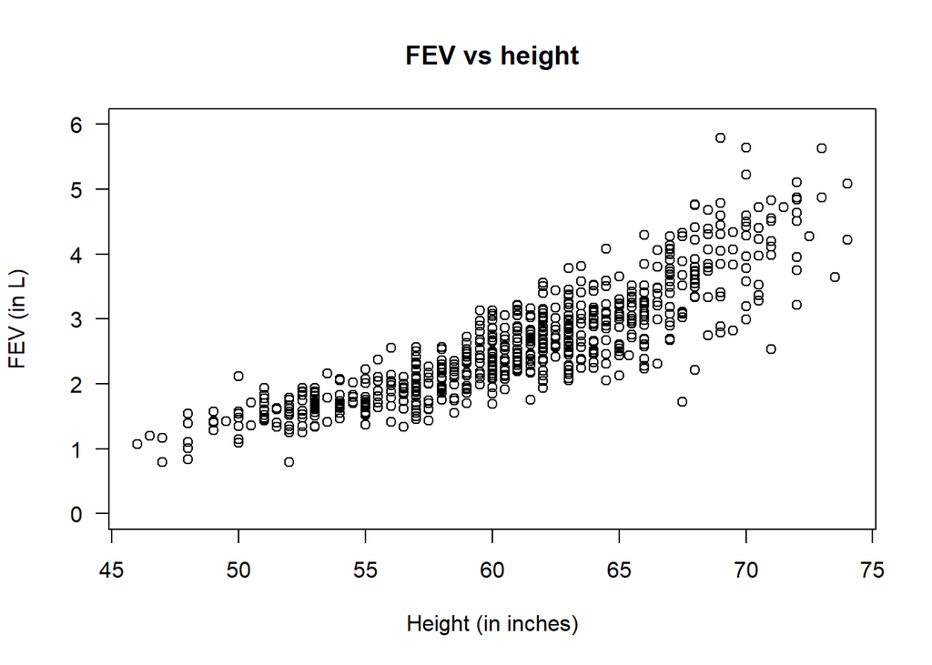

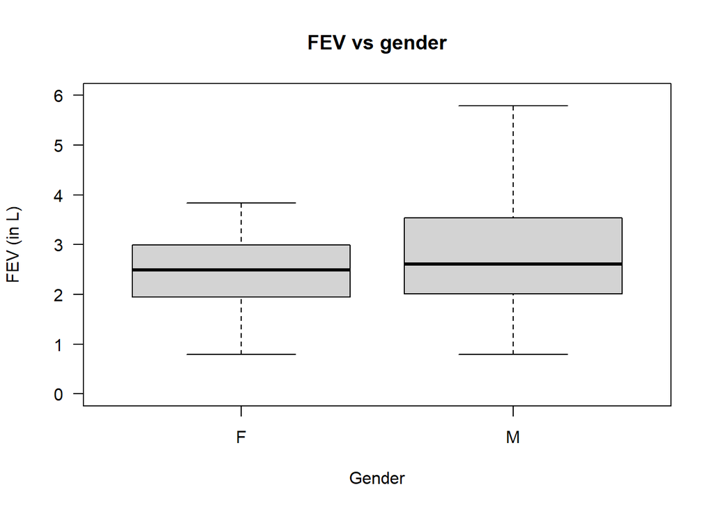

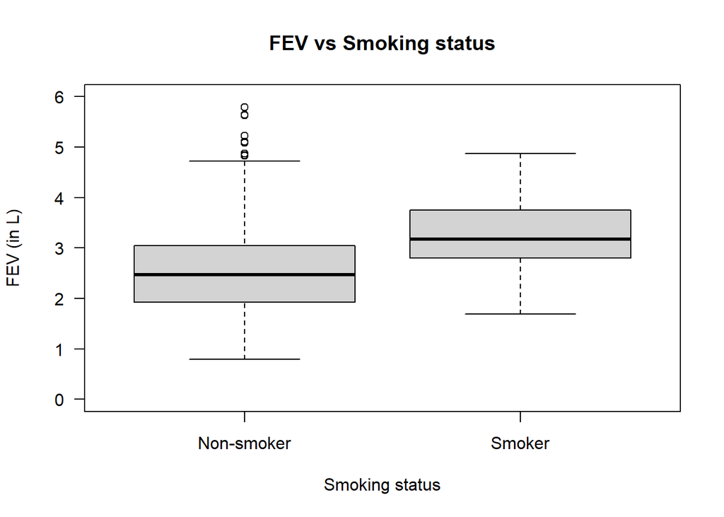

## regression models

generally, a regression model assumes that the mean response $\mu_i$ for observation i depends on the p predictors $x_{1i}, \dots, x_{pi}$ via some general function $f$ through a number of regression parameters $\beta_j$:
$$E[y_i]=\mu_i=f(x_{1i}, \dots, x_{pi};\beta_0, \dots, \beta_p)$$
commonly, the parameters $\beta_j$ are assumed to combine the effects of predictors linearly, thus the systematic component takes a more specific form

$$\mu_i=f(\beta_0+\beta_1x_{1i}+\dots+\beta_px_{pi})$$
so called linear regression models. There are two special cases of regression models linear in the parameters well studies:

- linear regression models: the systematic component of a linear regression model assumes the form $E[y_i]=\mu_i=\beta_0+\beta_1x_{1i}+\dots+\beta_px_{pi}$ while the randomness is assumed to be constant $\sigma^2$ about $\mu_i$
- generalized linear models: the systematic component of a generalized linear model assumes the form $g(\mu_i)=\beta_0+\beta_1x_{1i}+\dots+\beta_px_{pi}$ where $g(\cdot)$ is monotonic, differentiable function, called **link function**. the randomness is explained by assuming y comes from a specific family of pdf.

## purpose of a statistical model: prediction vs interpretation

the role of a statistical model is to accurately represent the important systematic and random features of the data. The purpose of developing statistical models can be two-fold:

- prediction: to provide accurate predictions from new or future data
- understanding and interpretation: to understand how variable relate to each other

## accuracy vs parsimony

in general, an adequate statistical model balances two criteria:

- accuracy: the model should accurately describe both the systematic and random components
- parsimony: the model should be as simple as possible for better understanding and interpretability
  - overfitting; follow details, fit the data extremely well but poor generalization performance for future data
  - underfitting: model is too simple to capture data features

## experiemnts vs observational studies

“All models must be used and understood within limitations imposed by how the data were collected.” the method of data collection affects the conclusions that can be drawn from the analysis.

in an observational study, researchers may use elaborate equipment to collect physical measures or ask well designed questions, but do not control the process being observed. Observational studies generally only permit conclusions about associations, not a cause-and-effect.

in a designed experiment, researchers fo intervene to control the values of the exploratory variables that appear in the data such that they are able to determine which experimental condition is applied to each subject. A well-designed randomized experiment allows for cause-and-effect relationships.

statistical models treat experimental and observational studies the same way, and the statistical conclusions are similar. However, the scientific conclusions from experiments are usually much stronger. The best we can do in an observational study is to collect as many extraneous variables that are likely to affect the response, so that as many uncontrolled effects can be adjusted for.

# linear regression models

## model definition

$$\begin{cases} var[y_i]=\sigma^2/w_i \\ \mu_i=\beta_0+\sum_{j=1}^{p}\beta_jx_{ji} \end{cases}$$

- simple linear regression model: when $p'=2$
- ordinary linear regression model: when all prior weights $w_i=1$
- weighted linear regression model: when prior weights are not equal
- multiple linear regression model

necessary assumptions for establishing linear regression models are:

- suitability: the same regression model is appropriate for all observations [outliers]
- linearity: the true relationship between $\mu$ and each continuous predictor is linear
- constant variance
- independence: the responses y are independent of each other

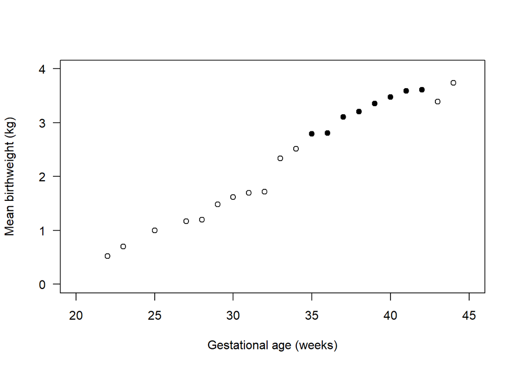

```
##
## Call:
## lm(formula = Weight ~ Age, data = gestation, weights = Births)
##
## Weighted Residuals:
##      Min       1Q   Median       3Q      Max
## -1.62979 -0.60893 -0.30063 -0.08845  1.03880
##
## Coefficients:
##              Estimate Std. Error t value Pr(>|t|)
## (Intercept) -2.678389   0.371172  -7.216 7.49e-07 ***
## Age          0.153759   0.009493  16.197 1.42e-12 ***
## ---
## Signif. codes:  0 '***' 0.001 '**' 0.01 '*' 0.05 '.' 0.1 ' ' 1
##
## Residual standard error: 0.7753 on 19 degrees of freedom
## Multiple R-squared:  0.9325, Adjusted R-squared:  0.9289
## F-statistic: 262.3 on 1 and 19 DF,  p-value: 1.416e-12
```

```
##
## Call:
## lm(formula = Weight ~ Age, data = gestation)
##
## Residuals:
##     Min      1Q  Median      3Q     Max
## -0.4179 -0.1176  0.0628  0.1435  0.2640
##
## Coefficients:
##              Estimate Std. Error t value Pr(>|t|)
## (Intercept) -3.049879   0.232945  -13.09 5.87e-11 ***
## Age          0.159483   0.006778   23.53 1.63e-15 ***
## ---
## Signif. codes:  0 '***' 0.001 '**' 0.01 '*' 0.05 '.' 0.1 ' ' 1
##
## Residual standard error: 0.1999 on 19 degrees of freedom
## Multiple R-squared:  0.9668, Adjusted R-squared:  0.9651
## F-statistic: 553.7 on 1 and 19 DF,  p-value: 1.627e-15
```

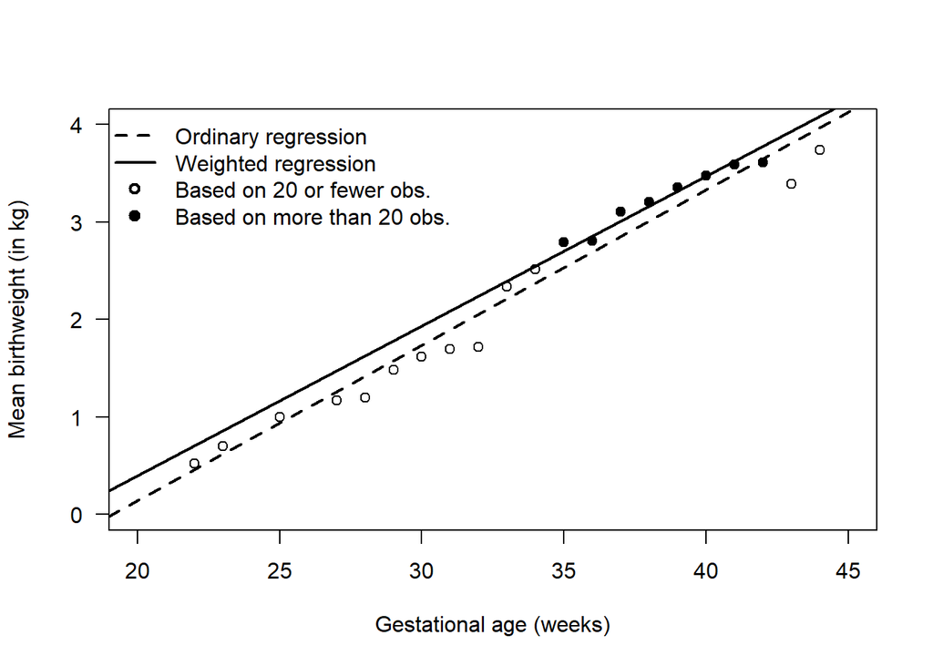

## coefficient estimates

consider the case of simple linear regression where the intercept and slope as well as the variance need to be estimated.

for any given intercept and slope, the deviations between the observed data and the model $\mu_i$ are given by $e_i=y_i-\mu_i=y_i-\beta_0-\sum_{j=1}^{p}\beta_jx_{ji}$. To summarize the deviations, square them to avoid negative quantities then sum them:

$$S(\beta_0, \beta_1)=\sum_{i}^{n}w_ie_i^2=\sum_{i}^{n}w_i(y_i-\mu_i)^2=\sum_{i}^{n}w_i(y_i-\beta_0-\beta_1x_i)^2$$
The non-negative weights $w_i$ may be used to weight observations according to their precision; S summarizes how far the fitted line deviates from the observations.

intuitively, the least-squares estimators of $\beta_j$ can be found by minimizing S.

using calculus, solving
$$\frac{\partial S}{\partial \beta_0}=0 \Rightarrow \hat{\beta_0}; \frac{\partial S}{\partial \beta_1}=0 \Rightarrow \hat{\beta_1}$$
least-squares estimators are unbiased; the fitted means are given by $\hat{\mu}_i=\hat{\beta_0}+\hat{\beta_1}x_i$ for $i=1,\dots,n$.

the minimized value of S, evaluated at the least-squares estimates, is called **residual sum-of-squares (RSS)**:

$$\text{RSS}=\sum_{i}^{n}w_i(y_i-\beta_0-\beta_1x_i)^2 \bigg |_{\hat{\beta_0}, \hat{\beta_1}}=\sum_{i}^{n}w_i(y_i-\hat{\beta}_0-\hat{\beta}_1x_i)^2$$
where $r_i=y_i-\hat{\mu}_i$ is called the **raw residuals**.

## model comparison

### nested: anova

```
##   ModelA   ModelB
## 28.91982 13.73356
```

```
## [1] 358.8249
```

```
## [1] 1.128849e-105
```

```
## Analysis of Variance Table
##
## Model 1: log(FEV) ~ Age + Smoke
## Model 2: log(FEV) ~ Age + Ht + Gender + Smoke
##   Res.Df    RSS Df Sum of Sq      F    Pr(>F)
## 1    651 28.920
## 2    649 13.734  2    15.186 358.82 < 2.2e-16 ***
## ---
## Signif. codes:  0 '***' 0.001 '**' 0.01 '*' 0.05 '.' 0.1 ' ' 1
```

### non-nested: AIC/BIC

```
## [1]     3.000 -2033.551
```

```
## [1]     3.000 -2470.728
```

```
## [1]     3.000 -2020.102
```

```
## [1]     3.000 -2457.278
```

## model selection

```
## Single term deletions
##
## Model:
## log(FEV) ~ Age + Ht + Gender + Smoke
##        Df Sum of Sq    RSS     AIC  F value    Pr(>F)
## <none>              13.734 -2516.6
## Age     1    1.0323 14.766 -2471.2  48.7831 7.096e-12 ***
## Ht      1   13.7485 27.482 -2064.9 649.7062 < 2.2e-16 ***
## Gender  1    0.1325 13.866 -2512.3   6.2598   0.01260 *
## Smoke   1    0.1027 13.836 -2513.7   4.8537   0.02794 *
## ---
## Signif. codes:  0 '***' 0.001 '**' 0.01 '*' 0.05 '.' 0.1 ' ' 1
```

```
## Single term additions
##
## Model:
## log(FEV) ~ Smoke
##        Df Sum of Sq    RSS     AIC  F value    Pr(>F)
## <none>              68.192 -1474.5
## Age     1    39.273 28.920 -2033.5  884.045 < 2.2e-16 ***
## Ht      1    53.371 14.821 -2470.7 2344.240 < 2.2e-16 ***
## Gender  1     2.582 65.611 -1497.8   25.616 5.426e-07 ***
## ---
## Signif. codes:  0 '***' 0.001 '**' 0.01 '*' 0.05 '.' 0.1 ' ' 1
```

```
## Start:  AIC=-2516.58
## log(FEV) ~ Age + Ht + Gender + Smoke
##
##                Df Sum of Sq    RSS     AIC
## <none>                      13.734 -2516.6
## + Smoke:Age     1  0.040136 13.693 -2516.5
## + Ht:Gender     1  0.006336 13.727 -2514.9
## + Smoke:Gender  1  0.003488 13.730 -2514.7
## + Age:Gender    1  0.003119 13.730 -2514.7
## + Smoke:Ht      1  0.001732 13.732 -2514.7
## + Age:Ht        1  0.001455 13.732 -2514.6
```

```
## Start:  AIC=-2507.58
## log(FEV) ~ (Smoke + Age + Ht + Gender)^2
##
##                Df Sum of Sq    RSS     AIC
## - Smoke:Gender  1  0.000626 13.671 -2509.6
## - Age:Gender    1  0.000859 13.671 -2509.5
## - Age:Ht        1  0.002852 13.674 -2509.4
## - Smoke:Ht      1  0.005607 13.676 -2509.3
## - Ht:Gender     1  0.007841 13.678 -2509.2
## <none>                      13.671 -2507.6
## - Smoke:Age     1  0.048232 13.719 -2507.3
##
## Step:  AIC=-2509.55
## log(FEV) ~ Smoke + Age + Ht + Gender + Smoke:Age + Smoke:Ht +
##     Age:Ht + Age:Gender + Ht:Gender
##
##              Df Sum of Sq    RSS     AIC
## - Age:Gender  1  0.000581 13.672 -2511.5
## - Age:Ht      1  0.003282 13.675 -2511.4
## - Ht:Gender   1  0.007945 13.679 -2511.2
## - Smoke:Ht    1  0.009919 13.681 -2511.1
## <none>                    13.671 -2509.6
## - Smoke:Age   1  0.047923 13.719 -2509.3
##
## Step:  AIC=-2511.52
## log(FEV) ~ Smoke + Age + Ht + Gender + Smoke:Age + Smoke:Ht +
##     Age:Ht + Ht:Gender
##
##             Df Sum of Sq    RSS     AIC
## - Age:Ht     1  0.003749 13.676 -2513.3
## - Smoke:Ht   1  0.009377 13.681 -2513.1
## - Ht:Gender  1  0.011841 13.684 -2512.9
## <none>                   13.672 -2511.5
## - Smoke:Age  1  0.047397 13.719 -2511.3
##
## Step:  AIC=-2513.34
## log(FEV) ~ Smoke + Age + Ht + Gender + Smoke:Age + Smoke:Ht +
##     Ht:Gender
##
##             Df Sum of Sq    RSS     AIC
## - Smoke:Ht   1  0.007326 13.683 -2515.0
## - Ht:Gender  1  0.008717 13.684 -2514.9
## <none>                   13.676 -2513.3
## - Smoke:Age  1  0.050584 13.726 -2512.9
##
## Step:  AIC=-2514.99
## log(FEV) ~ Smoke + Age + Ht + Gender + Smoke:Age + Ht:Gender
##
##             Df Sum of Sq    RSS     AIC
## - Ht:Gender  1  0.010484 13.693 -2516.5
## <none>                   13.683 -2515.0
## - Smoke:Age  1  0.044284 13.727 -2514.9
##
## Step:  AIC=-2516.49
## log(FEV) ~ Smoke + Age + Ht + Gender + Smoke:Age
##
##             Df Sum of Sq    RSS     AIC
## - Smoke:Age  1  0.040136 13.734 -2516.6
## <none>                   13.693 -2516.5
##
## Step:  AIC=-2516.58
## log(FEV) ~ Smoke + Age + Ht + Gender
```

```
## (Intercept)       Smoke         Age          Ht     GenderM
##     -1.9400     -0.0461      0.0234      0.0428      0.0293
```

```
## Start:  AIC=-2516.58
## log(FEV) ~ Age + Ht + Gender + Smoke
##
##                Df Sum of Sq    RSS     AIC
## <none>                      13.734 -2516.6
## + Smoke:Age     1  0.040136 13.693 -2516.5
## + Ht:Gender     1  0.006336 13.727 -2514.9
## + Smoke:Gender  1  0.003488 13.730 -2514.7
## + Age:Gender    1  0.003119 13.730 -2514.7
## + Smoke:Ht      1  0.001732 13.732 -2514.7
## + Age:Ht        1  0.001455 13.732 -2514.6
```

```
## (Intercept)         Age          Ht     GenderM       Smoke
##     -1.9400      0.0234      0.0428      0.0293     -0.0461
```

## case study 1

```
##       Country      Indus        Sugar            DMFT
##  Albania  : 1   Ind   :29   Min.   : 0.97   Min.   :0.300
##  Algeria  : 1   NonInd:61   1st Qu.:14.53   1st Qu.:1.600
##  Angolia  : 1               Median :33.79   Median :2.300
##  Argentina: 1               Mean   :30.14   Mean   :2.656
##  Australia: 1               3rd Qu.:44.32   3rd Qu.:3.350
##  Austria  : 1               Max.   :63.02   Max.   :8.100
##  (Other)  :84
```

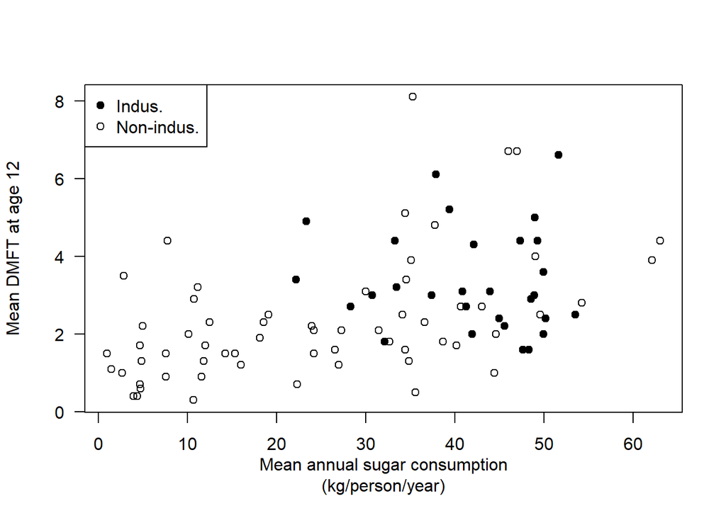

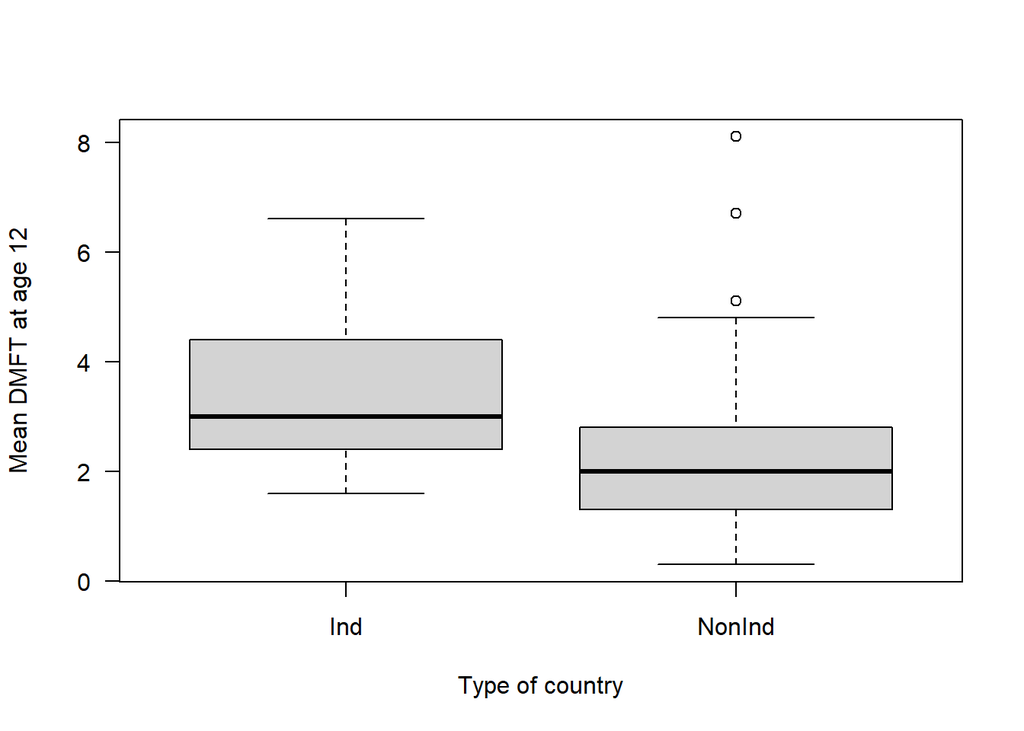

```
## Analysis of Variance Table
##
## Response: DMFT
##             Df  Sum Sq Mean Sq F value    Pr(>F)
## Sugar        1  49.836  49.836 26.3196 1.768e-06 ***
## Indus        1   1.812   1.812  0.9572   0.33065
## Sugar:Indus  1   6.674   6.674  3.5248   0.06385 .
## Residuals   86 162.840   1.893
## ---
## Signif. codes:  0 '***' 0.001 '**' 0.01 '*' 0.05 '.' 0.1 ' ' 1
```

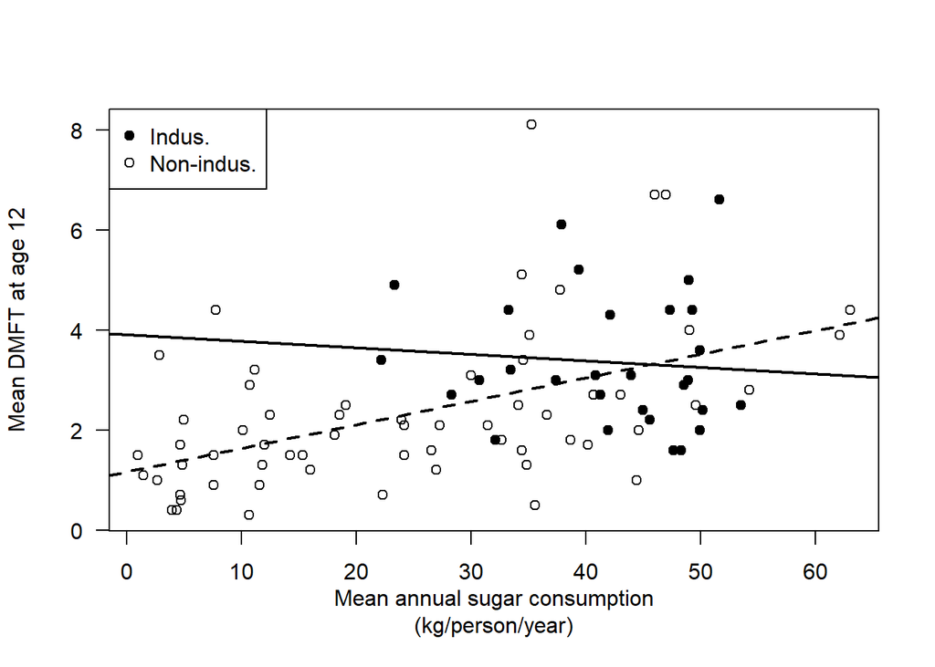

## diagnostics and model-building

### residual & leverage

```
##          Raw Standardized
##    0.1812849    1.0027232
```

```
##        629        631
## 0.02207842 0.02034224
```

```
## [1] 0.006116208
```

```
## [1] 0.006116208
```

```
##      629      631
## 3.609822 3.325956
```

```
##     Age   FEV Ht Gender  Smoke
## 629   9 1.953 58      M Smoker
## 631  11 1.694 60      M Smoker
```

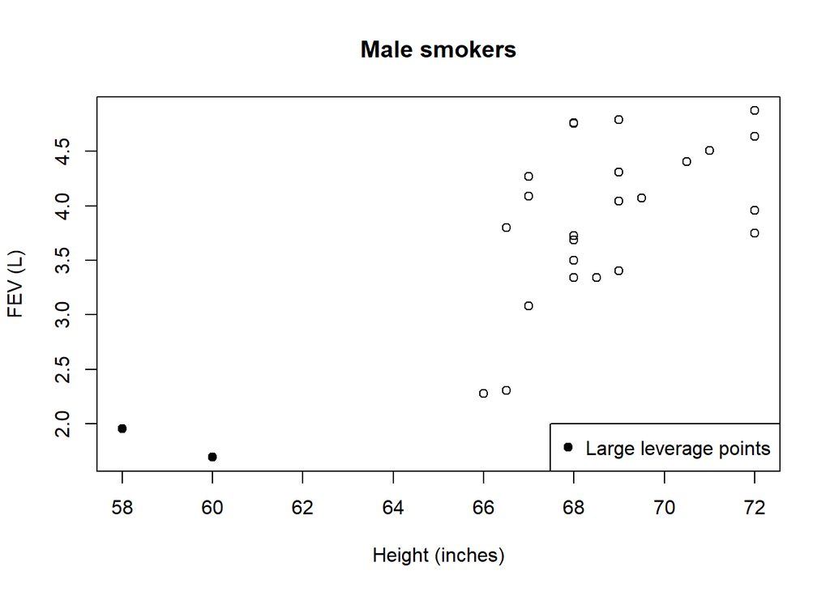

The two largest leverages correspond to the two unusual observations in the bottom left corner of the plot.

### residual plot

- residuals vs. $x_j$: linearity

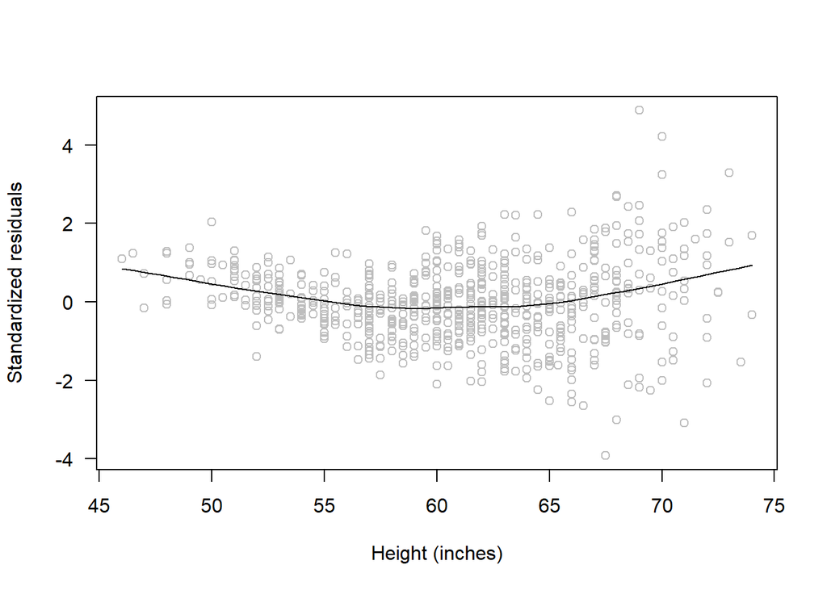

  slightly non-linear, and have increasing variance. This suggests that the model is poor.
- residuals vs. $\hat{\mu}$: constant variance

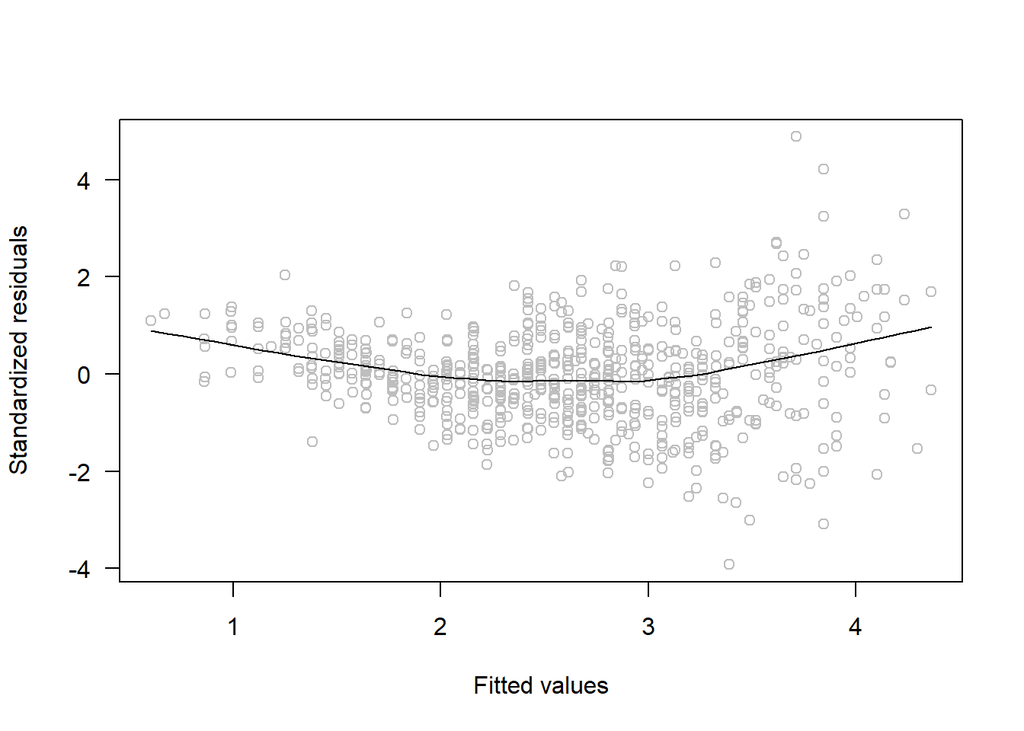

- Q-Q plot for normality

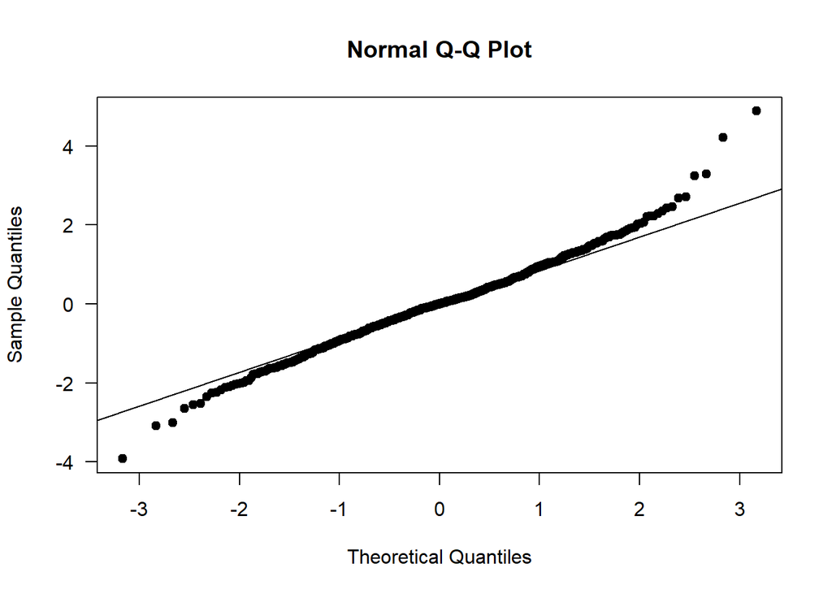

## remedies

### transforming y

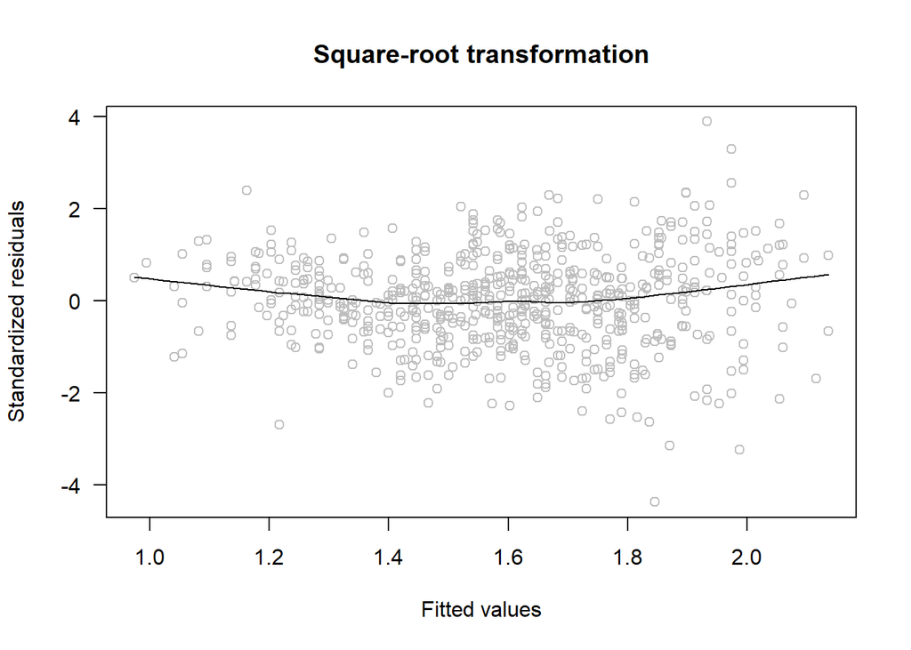

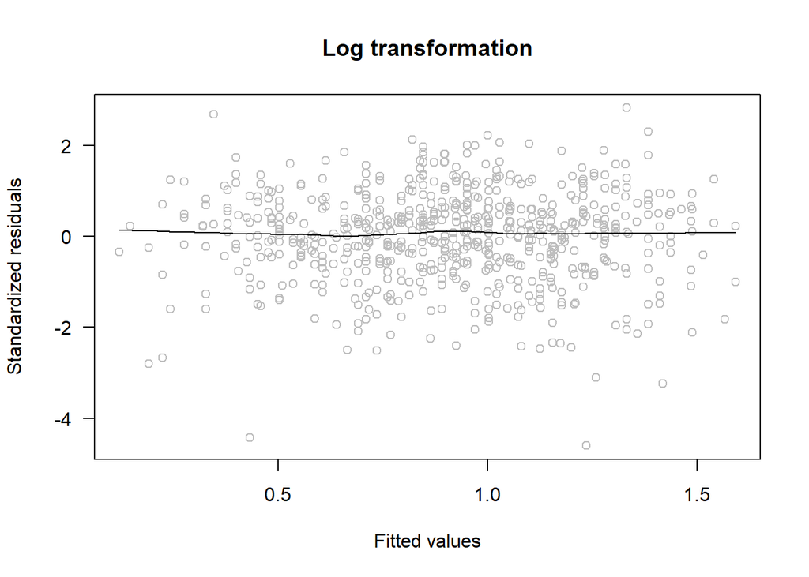

**Box-Cox transformation** finds the optimal $\lambda$ to achieve linearity, normality and constant variance simultaneously.

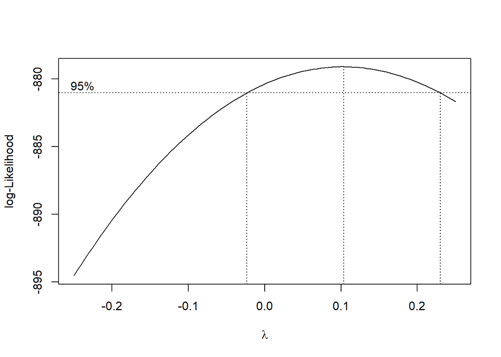

### transforming covariates

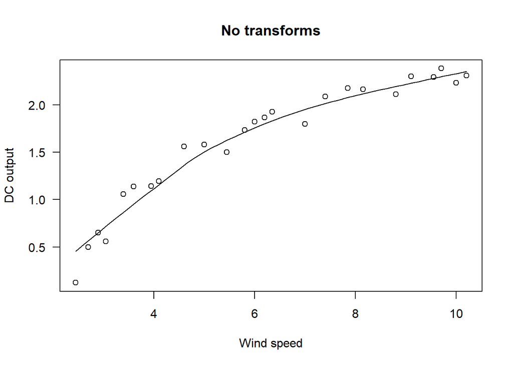

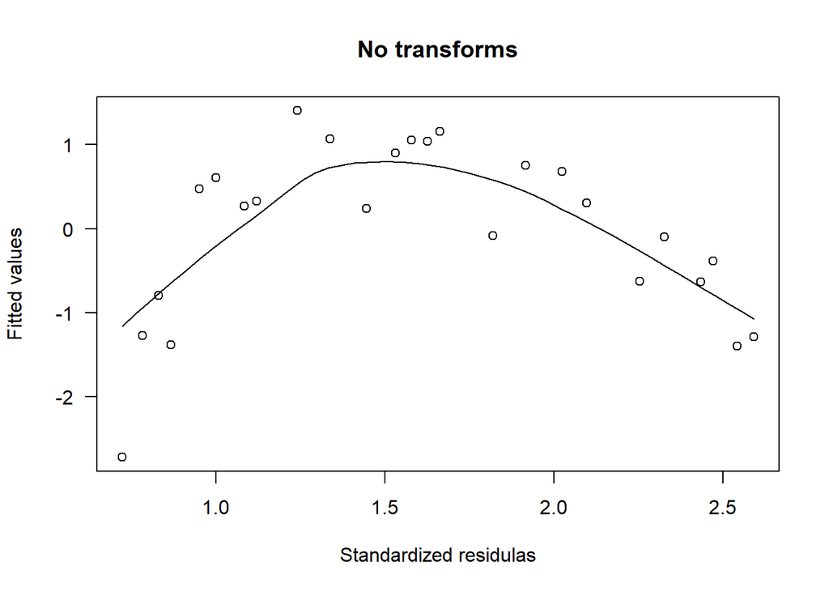

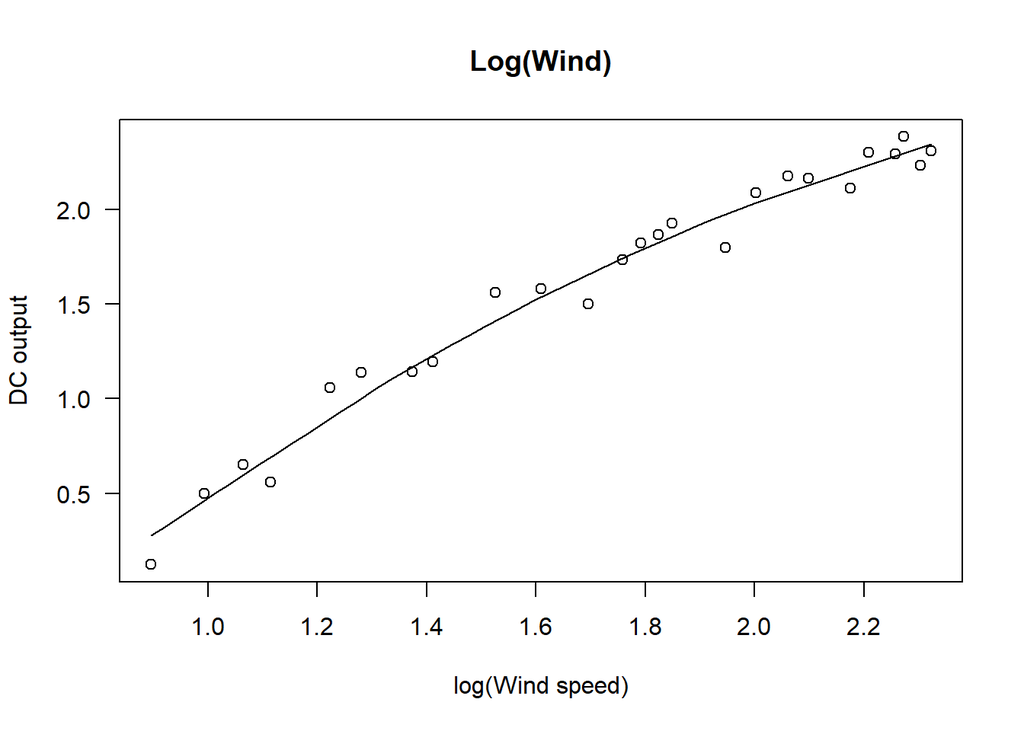

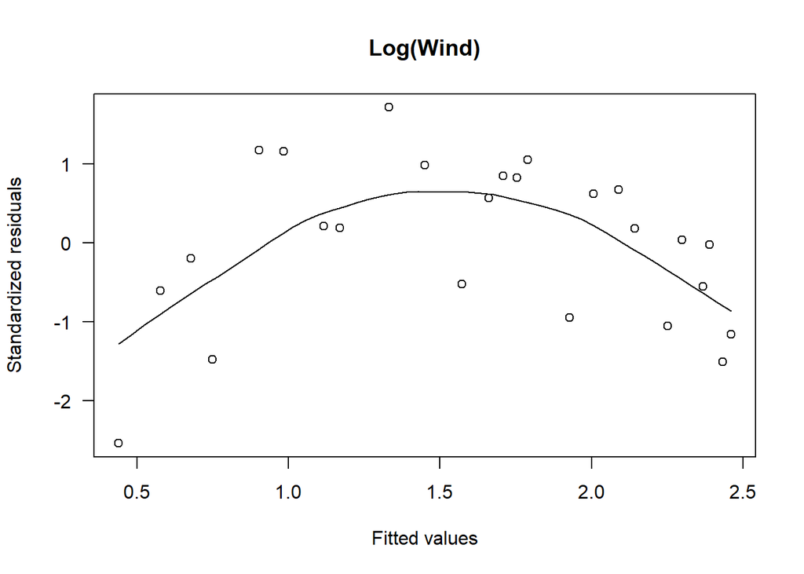

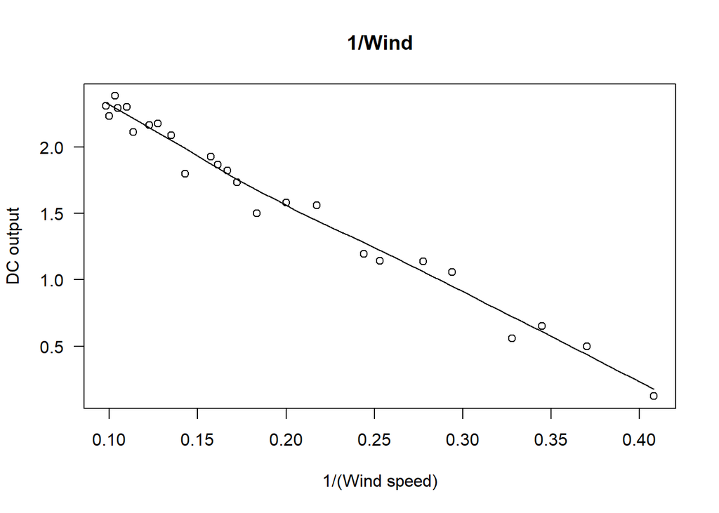

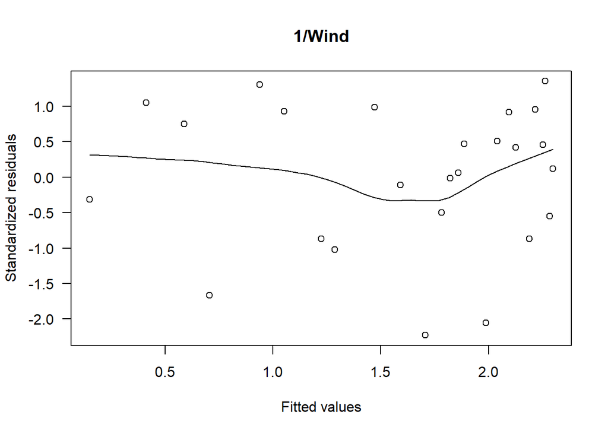

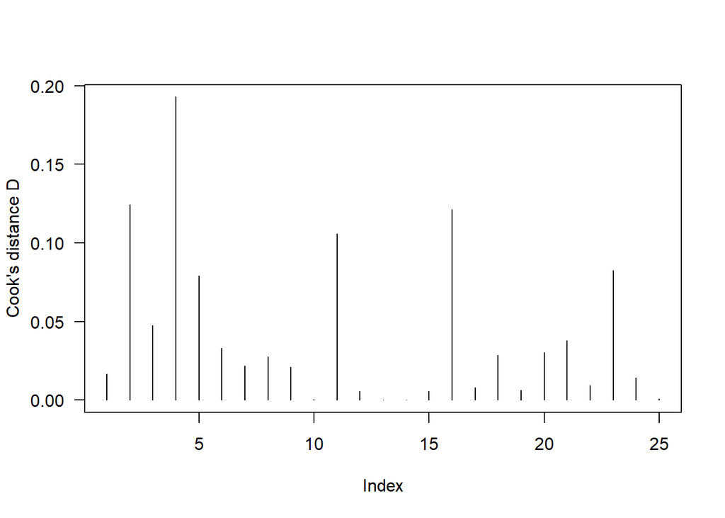

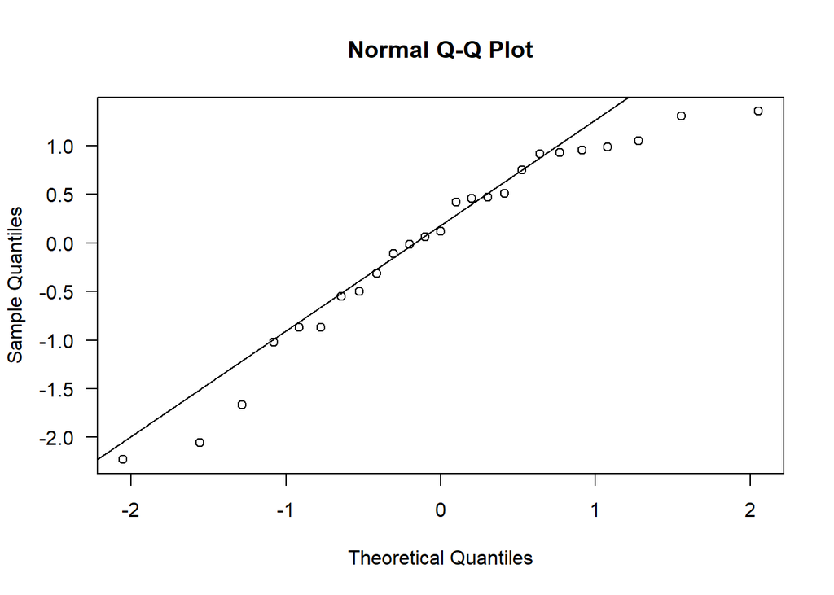

### polynomial trend

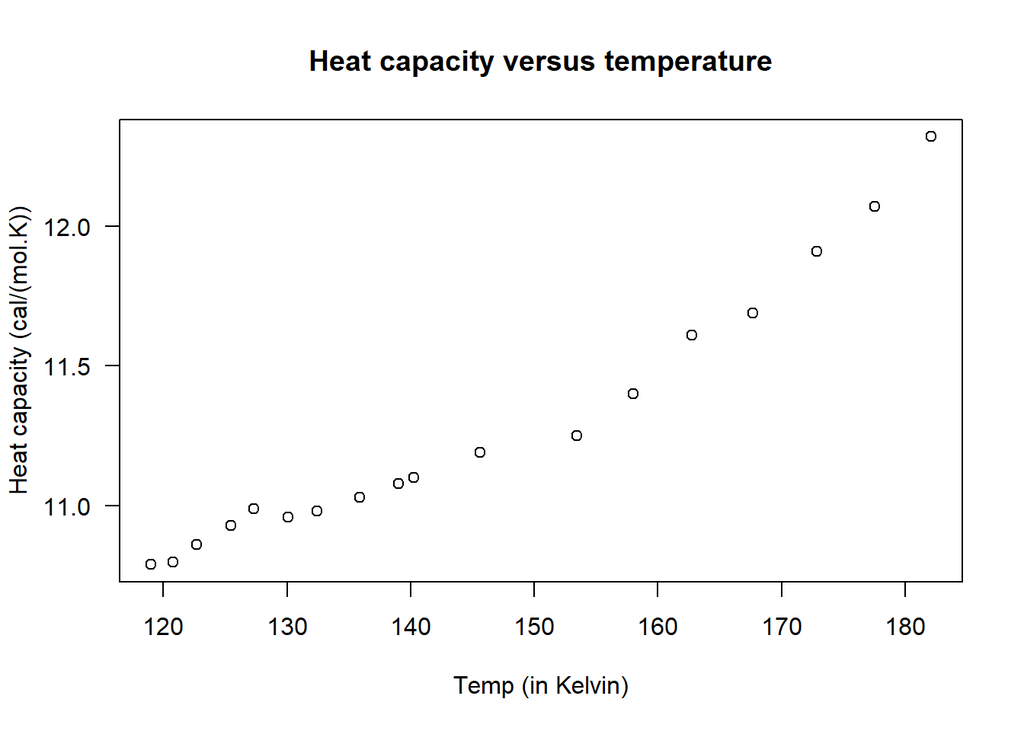

```
##             (Intercept)       Temp  I(Temp^2)
## (Intercept)   1.0000000 -0.9984975  0.9941781
## Temp         -0.9984975  1.0000000 -0.9985344
## I(Temp^2)     0.9941781 -0.9985344  1.0000000
```

Observe that the correlations between the two predictors are extremely close to plus or minus one.

More numerically stable polynomials are usually fitted, called orthogonal polynomials, using `poly()` in r.

```
##                  Estimate Std. Error   t value  Pr(>|t|)
## (Intercept)    11.2755556  0.0077737 1450.4766 < 2.2e-16 ***
## poly(Temp, 4)1  1.8409086  0.0329810   55.8173 < 2.2e-16 ***
## poly(Temp, 4)2  0.3968900  0.0329810   12.0339  2.02e-08 ***
## poly(Temp, 4)3  0.1405174  0.0329810    4.2606 0.0009288 ***
## poly(Temp, 4)4 -0.0556088  0.0329810   -1.6861 0.1156150
## ---
## Signif. codes:  0 '***' 0.001 '**' 0.01 '*' 0.05 '.' 0.1 ' ' 1
```

### regression splines

Natural smoothing splines are linear at the end points, and hence can be extrapolated in a predictable way outside the interval of the data used to estimate the curve. For this reason, natural smoothing splines are a good practical choice in most cases for fitting data-driven curves.

```
## [1]    4.0000 -117.1234
```

```
## [1]    4.0000 -119.2705
```

```
## [1]    4.0000 -117.1234
```

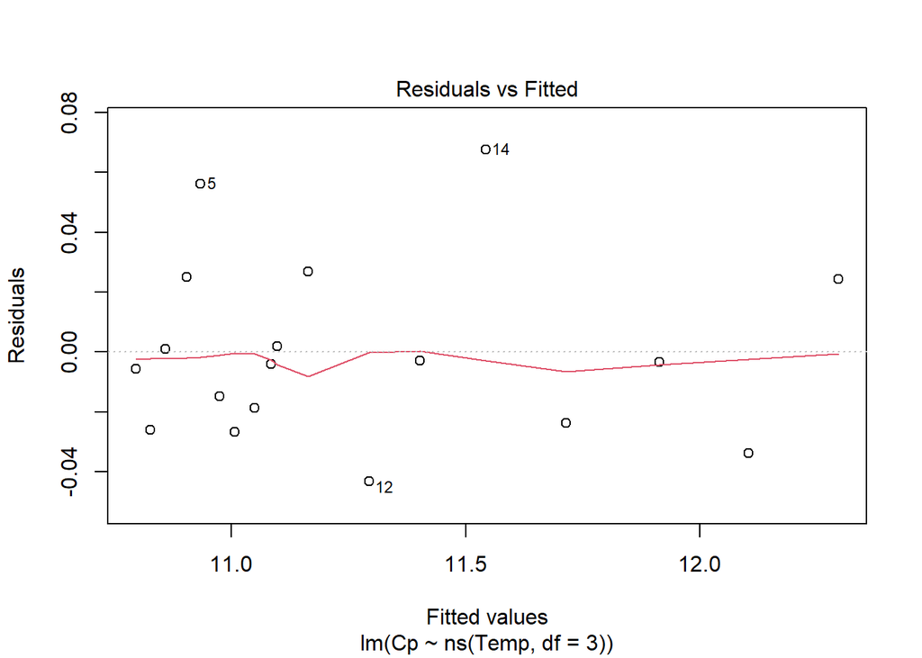

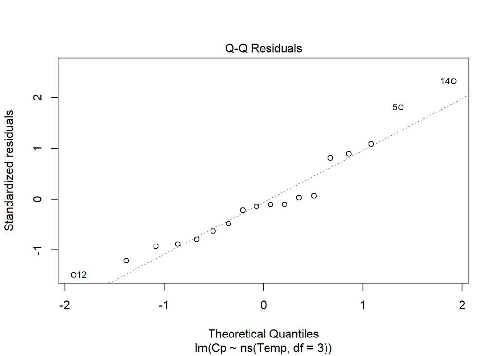

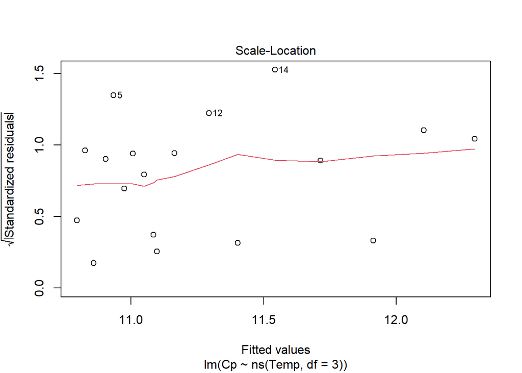

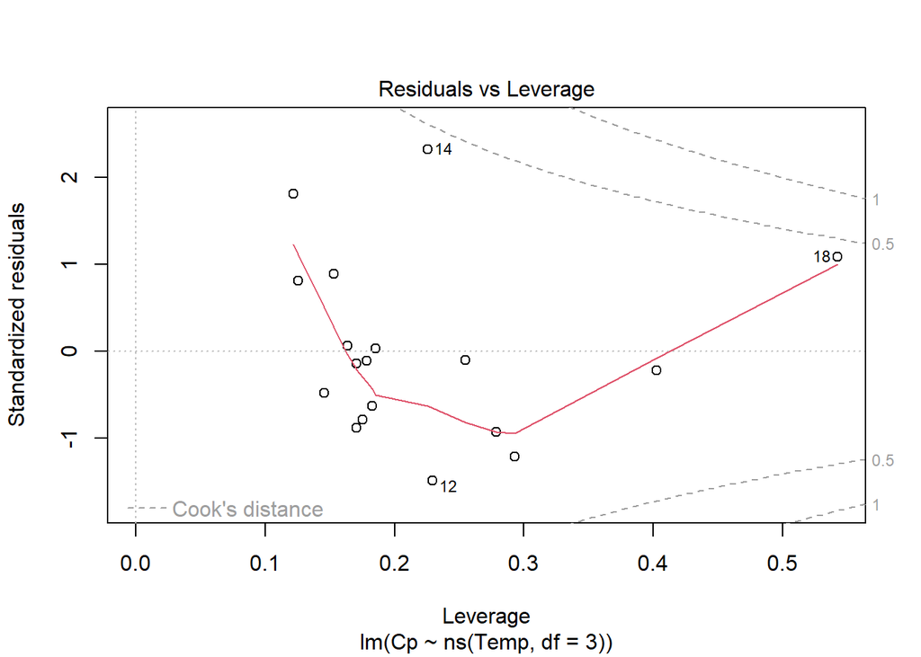